```python
import numpy as np
import pandas as pd
import requests
import seaborn as sns
import warnings
warnings.filterwarnings('ignore')

from matplotlib import pyplot as plt
plt.style.use('ggplot')
```

```python
url = 'https://api.apispreadsheets.com/api/dataset/congressional-voting/'

r = requests.get(url)
data = r.json()
df = pd.DataFrame.from_dict(data['data'], orient='columns')
df.sample(5)
```

|  | handicapped_infants | water_project_cost_sharing | adoption_of_the_budget_resolution | physician_fee_freeze | el_salvador_aid | religious_groups_in_schools | anti_satellite_test_ban | aid_to_nicaraguan_contras | mx_missile | immigration | synfuels_corporation_cutback | education_spending | superfund_right_to_sue | crime | duty_free_exports | export_administration_act_south_africa | political_party |
| --- | --- | --- | --- | --- | --- | --- | --- | --- | --- | --- | --- | --- | --- | --- | --- | --- | --- |
| 7 | n | y | n | y | y | y | n | n | n | n | n | n | y | y | ? | y | republican |
| 158 | n | y | n | y | y | y | n | n | n | y | n | y | y | y | n | n | republican |
| 178 | ? | n | y | n | n | n | y | y | y | y | y | ? | n | n | y | ? | democrat |
| 236 | n | n | y | n | n | n | y | y | y | n | n | n | n | n | y | y | democrat |
| 375 | n | y | n | y | y | y | n | n | n | n | y | y | n | y | n | n | democrat |

# Description

This data set includes votes for each of the U.S. House of Representatives Congressmen on the 16 key votes identified by the CQA in 1986. The CQA lists nine different types of votes: voted for, paired for, and announced for (these three simplified to y), voted against, paired against, and announced against (these three simplified to n), voted present, voted present to avoid conflict of interest, and did not vote or otherwise make a position known (these three simplified to an unknown disposition noted in the dataset as ?).

Missing values are filled in with '?' for nominal and -100000 for numerical attributes

```python
df.info()
```

```
<class 'pandas.core.frame.DataFrame'>
RangeIndex: 435 entries, 0 to 434
Data columns (total 17 columns):
 #   Column                                  Non-Null Count  Dtype
---  ------                                  --------------  -----
 0   handicapped_infants                     435 non-null    object
 1   water_project_cost_sharing              435 non-null    object
 2   adoption_of_the_budget_resolution       435 non-null    object
 3   physician_fee_freeze                    435 non-null    object
 4   el_salvador_aid                         435 non-null    object
 5   religious_groups_in_schools             435 non-null    object
 6   anti_satellite_test_ban                 435 non-null    object
 7   aid_to_nicaraguan_contras               435 non-null    object
 8   mx_missile                              435 non-null    object
 9   immigration                             435 non-null    object
 10  synfuels_corporation_cutback            435 non-null    object
 11  education_spending                      435 non-null    object
 12  superfund_right_to_sue                  435 non-null    object
 13  crime                                   435 non-null    object
 14  duty_free_exports                       435 non-null    object
 15  export_administration_act_south_africa  435 non-null    object
 16  political_party                         435 non-null    object
dtypes: object(17)
memory usage: 57.9+ KB
```

# How does Y look like?

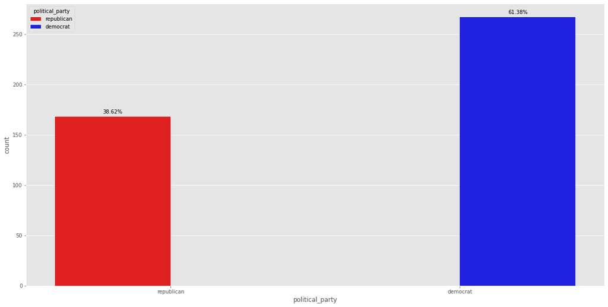

```python
palette = {'republican': 'red', 'democrat': 'blue'}
plt.figure(figsize=(20,10))
ax = sns.countplot(data=df, x='political_party', hue='political_party', palette=palette)
for p in ax.patches:
  height = p.get_height()
  if height > 0:
    ax.text(p.get_x()+p.get_width()/2.,
            height + 3,
            '{:1.2f}%'.format(height/len(df)*100),
            ha="center")
plt.show()
```

Immediately it is visible that democrats have advantage in numbers in comparison to republicans. It is very likely that this matter affects how people votes, so after deep analysis we will be able to predict if someone is democrat or republican by analysing their votes only.

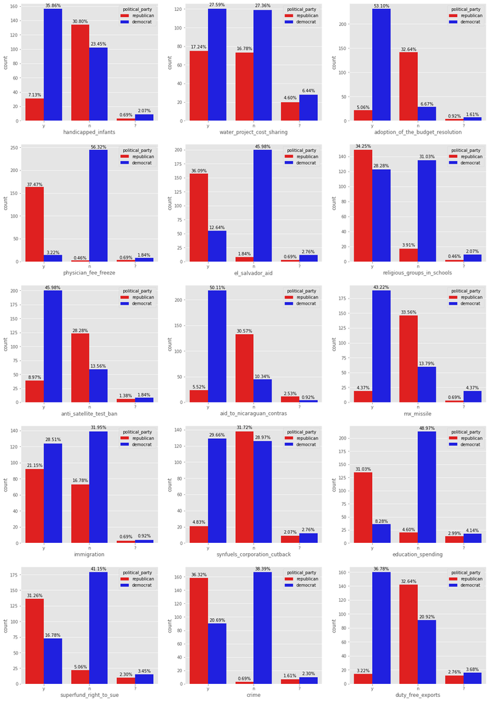

```python
cols = df.columns.drop('political_party')

def plot_countplots(columns):

  fig, axis = plt.subplots(len(columns) // 3,3, figsize=(20,30))
  for i in range(len(columns) // 3):
        for j in range(3):

          ax = sns.countplot(data=df, x=columns[i*3+j], hue='political_party',
                           palette = palette, ax=axis[i][j], order=['y','n','?'])
          for p in ax.patches:
              height = p.get_height()
              if height > 0:
                ax.text(p.get_x()+p.get_width()/2.,
                        height + 3,
                        '{:1.2f}%'.format(height/len(df)*100),
                        ha="center")
  plt.show()

plot_countplots(cols)
```

- `physician_fee_freeze` is the most divisive feature
- `water_project_cost_sharing` is a feature which has very regular distribution

# **Correlation**

To check if our assuptions about most dividing feature are correct, we've decided to add correlation matrix. By doing it we are able to see which features have common distribution, so we don't need them in data analysis.

We have to map our date, because basicaly we've got string data there and correlation won't work on such data. That's why we use dictionary 'party' which changes democrat and republican parties into, respectively, 2 and -2. All other values are mapped by dictionary val which swaps n for -1, ? for 0, y for 1.

```python
val = {'n':-1, '?':0, 'y':1}
party = {'democrat':2, 'republican':-2}

df_num=df.copy()
df_party = df_num['political_party'].copy()
df_num.drop('political_party', axis=1, inplace=True)

for column in df_num.columns:
  df_num[column] = df_num[column].map(val)

df_party = df_party.map(party)

df_num = pd.concat([df_num,df_party], axis=1)

df_num.head()
```

|  | handicapped_infants | water_project_cost_sharing | adoption_of_the_budget_resolution | physician_fee_freeze | el_salvador_aid | religious_groups_in_schools | anti_satellite_test_ban | aid_to_nicaraguan_contras | mx_missile | immigration | synfuels_corporation_cutback | education_spending | superfund_right_to_sue | crime | duty_free_exports | export_administration_act_south_africa | political_party |
| --- | --- | --- | --- | --- | --- | --- | --- | --- | --- | --- | --- | --- | --- | --- | --- | --- | --- |
| 0 | -1 | 1 | -1 | 1 | 1 | 1 | -1 | -1 | -1 | 1 | 0 | 1 | 1 | 1 | -1 | 1 | -2 |
| 1 | -1 | 1 | -1 | 1 | 1 | 1 | -1 | -1 | -1 | -1 | -1 | 1 | 1 | 1 | -1 | 0 | -2 |
| 2 | 0 | 1 | 1 | 0 | 1 | 1 | -1 | -1 | -1 | -1 | 1 | -1 | 1 | 1 | -1 | -1 | 2 |
| 3 | -1 | 1 | 1 | -1 | 0 | 1 | -1 | -1 | -1 | -1 | 1 | -1 | 1 | -1 | -1 | 1 | 2 |
| 4 | 1 | 1 | 1 | -1 | 1 | 1 | -1 | -1 | -1 | -1 | 1 | 0 | 1 | 1 | 1 | 1 | 2 |

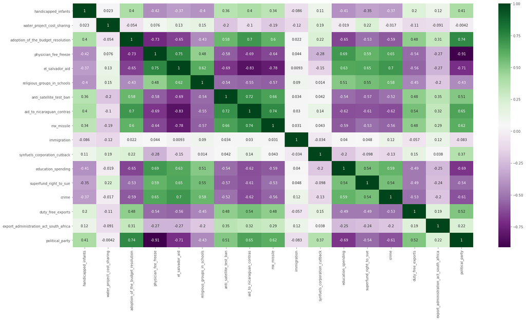

```python
plt.figure(figsize=(26,13))
df_num_cor=df_num.iloc[:,0:18]
c= df_num_cor.corr()
sns.heatmap(c,cmap='PRGn',annot=True)
```

*Summary*

- As we can clearly see, `physician_fee_freeze` is the most correlated value with political_party which indicates that we were initially right with our assumptions.
- We can also see that such variables like `adoption_of_the_budget_resolution`, `el_salvador_aid` and `education_spending` are also highly correlated with party.
- On the contrary we can exclude such variables like `water_project_cost_sharing` and `immigration`, because they are almost uncorrelated with the political party.